# Visualisierung semantischer Vektoren

Auf dieser Seite findest du Möglichkeiten zur Visualisierung semantischer Vektoren und ihrer Eigenschaften.

Der gesamte Code, den du hier findest, kann von dir 1:1 in R umgesetzt werden. Die größte Lernwirkung hat diese Einführung, wenn du möglichst alles einmal selbst in R durchführst.

# 01 Setup

Zunächst laden wir das `gdsm` Package. Hierin enthalten sind die Vektoren und Funktionen, die wir im Folgenden nutzen werden.

```r
library("gdsm")
```

Sobald das Package geladen ist, können wir den benötigten Vektorraum laden:

```r
data("gdsm_mat")
```

Im `gdsm_mat` Vektorraum sind simulierte Vektoren enthalten. Der Vektorraum enthält $20$ Vektoren mit je $50$ Dimensionen.

Nun können wir mit den Übungen starten.

# 02 tSNE Plots

Das grundlegende Problem bei der Darstellung von multi-dimensionalen Vektoren liegt in ihrer Dimensionalität: Mehr als 3 Dimensionen - 3D - können wir uns optisch nicht vorstellen. Entsprechend ist eine Darstellung aller Dimensionen nicht möglich.

Stattdessen kann man die Dimensionalität der Vektoren auf 2 oder 3 Dimensionen reduzieren. Dies geschieht z.B. bei s.g. tSNE Plots.

Das `gdsm` Package enthält eine Funktion, mit welcher ein Vektorraum entsprechend in ein Data Frame umgewandelt werden kann. Dieser Data Frame kann dann via `ggplot2` als Plot dargestellt werden.

```r
vis_data <- tSNE_df(gdsm_mat, dims = 2)
```

Der resultierende Data Frame hat folgende Struktur:

```r
vis_data[1:4, 1:2]
```

```
           tSNE1     tSNE2
var01  31.817665 -31.17477
var02 -38.256897 -12.69715
var03 -22.765140 -17.37669
var04  -7.270848  57.79661
```

Dieser wird dann zur Visualisierung genutzt:

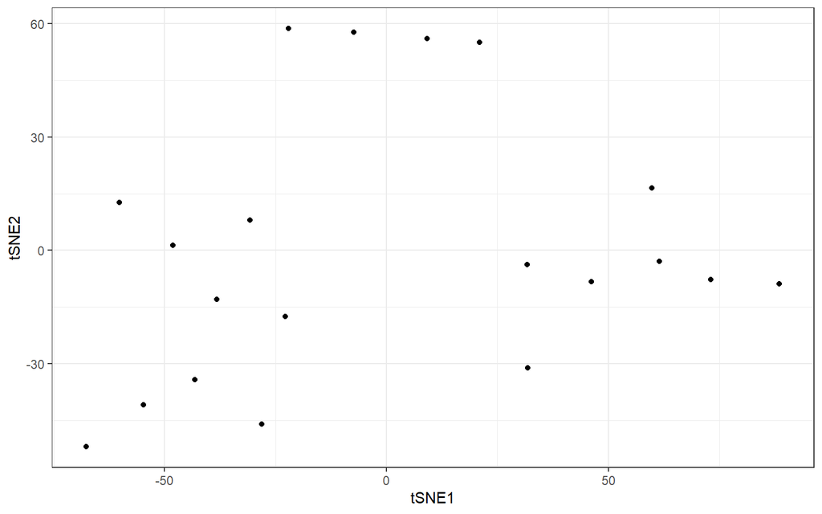

```r
library(ggplot2)


ggplot(vis_data) +
  geom_jitter(aes(x = tSNE1, y = tSNE2)) +
  theme_bw()
```

An sich ist ein solcher Plot noch nicht aussagekräftig. Unter Hinzunahme weiterer Faktoren oder Variablen können aber z.B. Cluster bestimmter Vektoren erkannt werden.

Nehmen wir im folgenden als Beispiel an, dass einige Vektoren Verben und andere Vektoren Nomen beschreiben:

```r
word_class <- c(rep("noun",3), "verb", rep("noun",2), "verb", rep("noun",2), "verb", rep("noun",5), "verb", rep("noun",4))
```

In einem echten Setting ergeben sich die interessanten Variablen aus der Forschungsfrage. Hier kombinieren wir nun die Daten:

```r
vis_data$word_class <- word_class
```

Nun können wir die interessante Variable in den Plot aufnehmen:

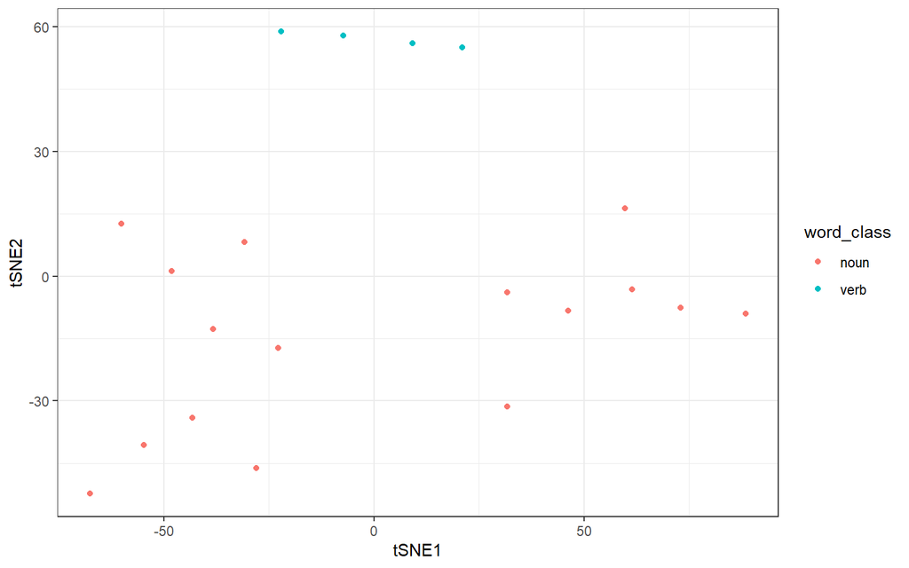

```r
library(ggplot2)


ggplot(vis_data) +
  geom_jitter(aes(x = tSNE1, y = tSNE2, color = word_class)) +
  theme_bw()
```

Wir stellen fest, dass die Vektoren der Verben clustern, und die Vektoren der Nomen sich woanders befinden. Während dieses Beispiel absichtlich so konstruiert ist, finden sich solche Cluster durchaus auch in echten Daten.

## Aufgaben

Erstelle den oben aufgezeigten Plot. Sieht deiner anders aus als der hier enthaltene?

Erstelle dann einen Plot mit 3 Dimensionen. Nutze zur Darstellung folgenden `ggplot` und `gg3D` Code:

```r
# install if required:
# devtools::install_github("AckerDWM/gg3D")

library(gg3D)

ggplot(vis_data2, aes(x = tSNE1, y = tSNE2, z = tSNE3)) +
  axes_3D() +
  stat_3D() +
  theme_bw()
```

**Lösung**

```r
vis_data2 <- tSNE_df(gdsm_mat, dims = 3)

# install if required:
# devtools::install_github("AckerDWM/gg3D")

library(gg3D)

ggplot(vis_data2, aes(x = tSNE1, y = tSNE2, z = tSNE3)) +
  axes_3D() +
  stat_3D() +
  theme_bw()
```

# 03 Entfernungs-Plots

Entfernungen wie der Euklidische Abstand und die Manhattan-Distanz können u.a. wie im folgenden Beispiel dargestellt werden.

Zunächst werden Daten benötigt. Hier nutzen wir den Euklidischen Abstand. Da wir diesen zu allen anderen Vektoren benötigen, nutzen wir die Funktion, die eigentlich zum Finden der nächsten Nachbarn gedacht ist:

```r
data <- find_nn("var01", gdsm_mat,
          n = 20,               # da es 20 Vektoren gibt
          method = "euclid")

head(data)
```

```
    euclid nearest_neighbor
1 23.53553            var19
2 23.64620            var18
3 24.53218            var11
4 24.71685            var03
5 26.08180            var13
6 26.30406            var09
```

Die berechneten Werte können dann dargestellt werden:

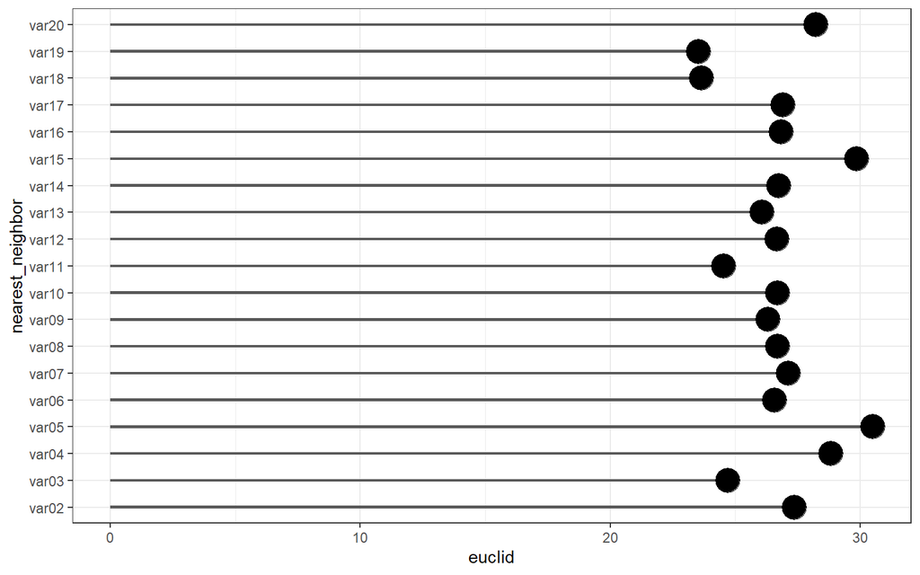

```r
ggplot(data) +
  geom_bar(aes(x = nearest_neighbor, y = euclid), stat="identity", width = 0.1) +
  geom_point(aes(x = nearest_neighbor, y = euclid), size = 7) +
  coord_flip() +
  theme_bw()
```

## Aufgaben

Erstelle einen äquivalenten Plot mit Manhattan-Distanz-Werten.

**Lösung**

```r
data <- find_nn("var01", gdsm_mat,
          n = 20,               # da es 20 Vektoren gibt
          method = "manhat")

ggplot(data) +
  geom_bar(aes(x = nearest_neighbor, y = manhat), stat="identity", width = 0.1) +
  geom_point(aes(x = nearest_neighbor, y = manhat), size = 7) +
  coord_flip() +
  theme_bw()
```

# 04 Darstellung der Kosinus-Ähnlichkeit

Kosinus-Ähnlichkeit lässt sich besonders dann gut darstellen, wenn es um zwei Gruppen mit je zwei Subgruppen geht. Nehmen wir als Beispiel an, dass unsere Gruppen A und B heißen. In beiden Gruppen gibt es Subgruppen: C und D. Nun berechnen wir die Ähnlichkeit von AC und AD sowie von BC und BD:

```r
# Simulieren der Vektoren - in "echten" Situationen sind diese selbstverständlich nicht simuliert

vectors_AC <- random_matrix()
vectors_AD <- random_matrix()

vectors_BC <- random_matrix()
vectors_BD <- random_matrix()

# Berechnen der Ähnlichkeiten

df_A <- data.frame()

for (i in 1:nrow(vectors_AC)) {
  df_A[i,1] <- cosim(vectors_AC[i,], vectors_AD[i,])
}


df_B <- data.frame()

for (i in 1:nrow(vectors_BC)) {
  df_B[i,1] <- cosim(vectors_BC[i,], vectors_BD[i,])
}

# Modifizieren der Daten

df_complete <- rbind(df_A, df_B)
df_complete$group <- c(rep("A",25),rep("B",25))
```

Nun können die berechneten Kosinus-Ähnlichkeiten dargestellt werden. Dies kann z.B. durch einen Boxplot geschehen:

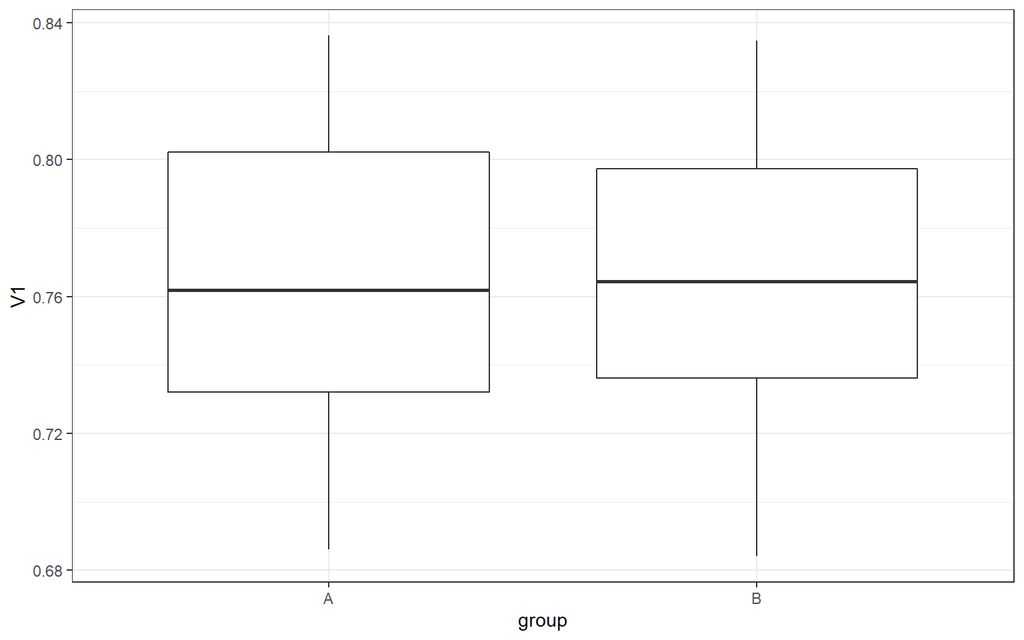

```r
ggplot(df_complete) +
  geom_boxplot(aes(x = group, y = V1)) +
  theme_bw()
```

## Aufgaben

Erstelle den oben gezeigten Plot für unterschiedliche zufällige Vektoren. Nutze dafür den obigen Code.